# ggplot - day 1 homework

```r
library(ggplot2)
library(CodeClanData)
```

QikBit is a start-up company producing low cost fitness trackers. Their flagship product, the KwikBit Unit1 (spot the mistake on the patent form) reproduces the functionality of the best in class commercial fitness trackers, but is cheap to make. They are currently preparing to pitch to a potential investor and require a selection of charts to include in their presentation and promotional materials.

The data for this assignment is provided in the CodeClanData package.

**qb_revenue_breakdown**  
**qb_monthly_sales**  
**qb_competitors**

1. Take the data in the dataset qb_revenue_breakdown and make a stacked bar chart showing the sources of revenue across the two years in the dataset.

```r
head(qb_revenue_breakdown)
```

|  | Product | Year | Revenue |
| --- | --- | --- | --- |
| 1 | Trackers | 2019 | 8994 |
| 2 | Smart Watches | 2019 | 12003 |
| 3 | Accessories | 2019 | 5250 |
| 4 | Subscription Services | 2019 | 3750 |
| 5 | Trackers | 2018 | 8004 |
| 6 | Smart Watches | 2018 | 11000 |

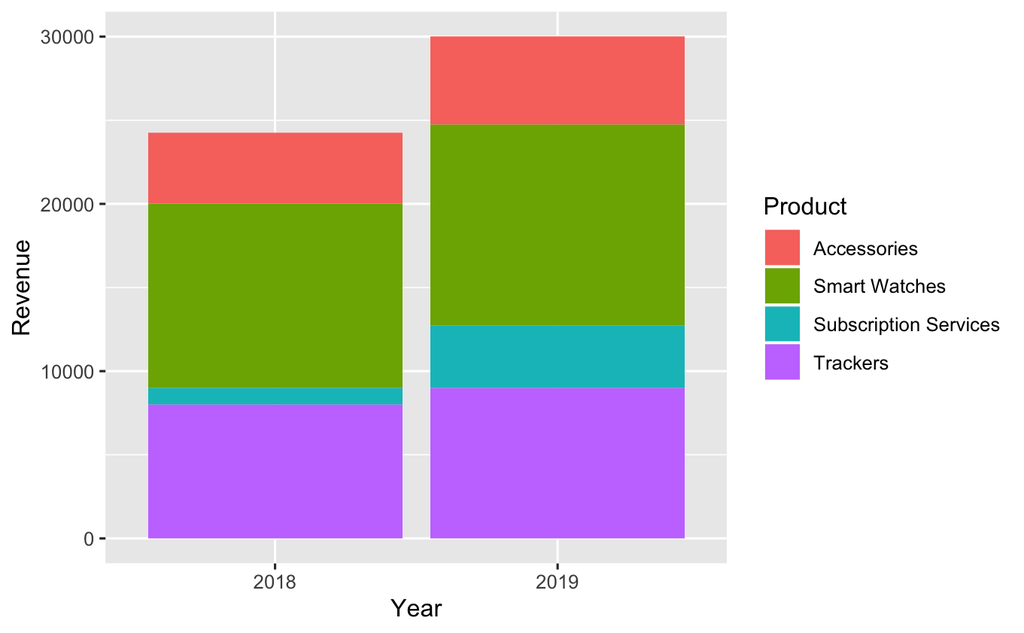

```r
ggplot(qb_revenue_breakdown) +
  aes(x = Year, y = Revenue, fill = Product) +
  geom_bar(stat = "identity")
```

2. Make a line chart showing monthly sales of the “flagship product” - the KwikBit Unit1 - over the last year. This data is inside qb_monthly_sales, but you will need to use subset.

```r
head(qb_monthly_sales)
```

|  | Date | Cashflow | Amount |
| --- | --- | --- | --- |
| 1 | 2019-07-01 | Kwikbit Unit 1 Sales | 601.74 |
| 2 | 2019-06-01 | Kwikbit Unit 1 Sales | 567.89 |
| 3 | 2019-05-01 | Kwikbit Unit 1 Sales | 536.00 |
| 4 | 2019-04-01 | Kwikbit Unit 1 Sales | 550.78 |
| 5 | 2019-03-01 | Kwikbit Unit 1 Sales | 526.03 |
| 6 | 2019-02-01 | Kwikbit Unit 1 Sales | 584.22 |

[figure not shown]

3. Make a line chart showing monthly revenue and costs over the last year. This data is also in qb_monthly_sales.

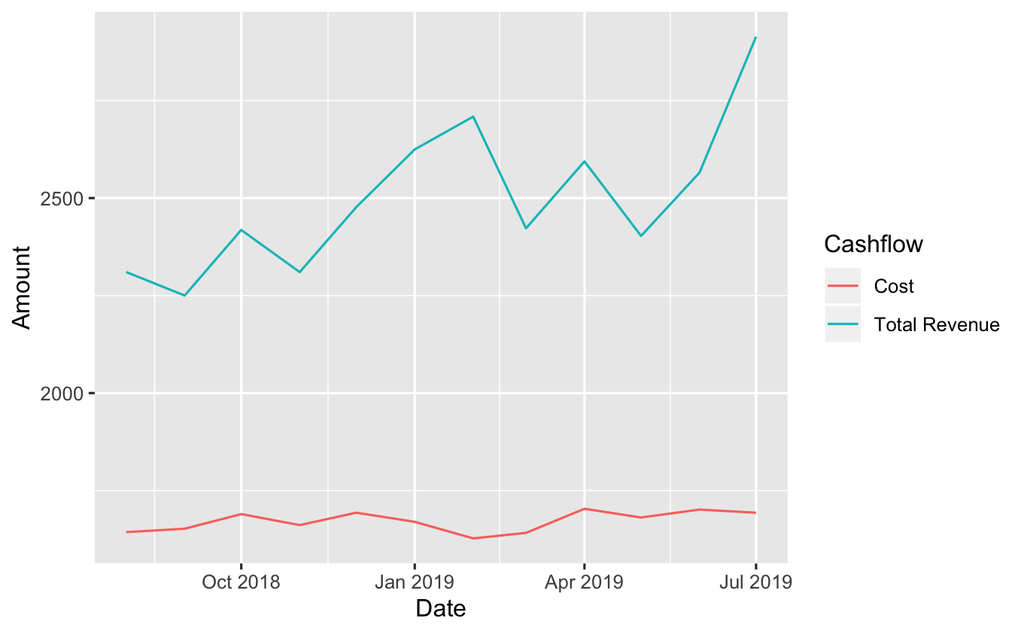

```r
ggplot(qb_monthly_sales) +
  aes(x = Date, y = Amount, colour = Cashflow) +
  geom_line(data = subset(qb_monthly_sales, Cashflow == "Cost" | Cashflow == "Total Revenue"))
```

Personal fitness trackers are a growth industry. One company does not dominate the field.

4. Show annual sales of personal fitness trackers over the last 5 years broken down by company as a ribbon plot (use geom_area). This data is in qb_competitors.

```r
head(qb_competitors)
```

|  | Company | Year | Revenue |
| --- | --- | --- | --- |
| 1 | Competitor 1 | 2019 | 2216000 |
| 2 | Competitor 2 | 2019 | 1760000 |
| 3 | Competitor 3 | 2019 | 1455000 |
| 4 | Competitor 4 | 2019 | 1229000 |
| 5 | Competitor 1 | 2018 | 2144400 |
| 6 | Competitor 2 | 2018 | 1440000 |

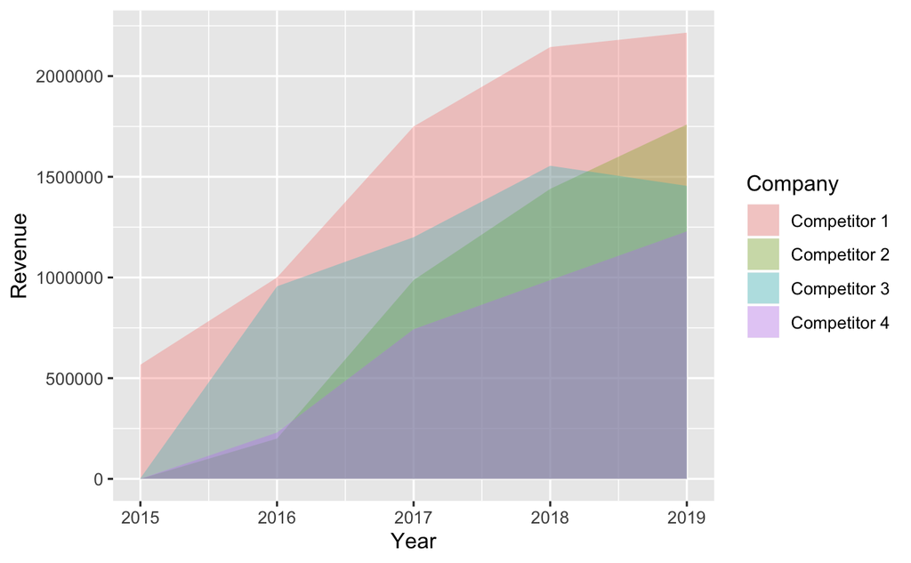

```r
ggplot(qb_competitors) +
  aes(x = Year, y = Revenue, fill = Company) +
  geom_area(position = "identity", alpha = 0.3)
```

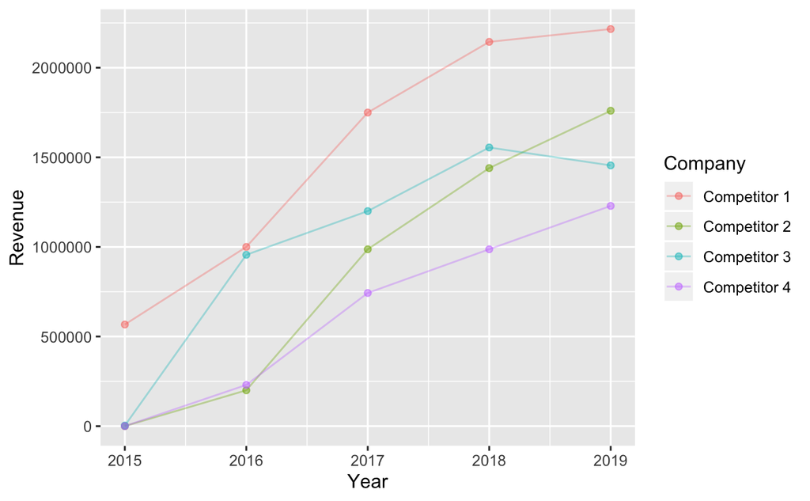

```r
ggplot(qb_competitors) +
  geom_line(aes(x = Year, y = Revenue, group = Company, colour = Company), alpha = 0.35) +
  geom_point(aes(x = Year, y = Revenue, colour = Company), alpha = 0.5)
```

Try out different ways of plotting these three datasets. Which graphs do you think are particularly effective at showing QikBit’s success?

**qb_revenue_breakdown**  
**qb_monthly_sales**  
**qb_competitors**

```r
head(qb_revenue_breakdown)
```

|  | Product | Year | Revenue |
| --- | --- | --- | --- |
| 1 | Trackers | 2019 | 8994 |
| 2 | Smart Watches | 2019 | 12003 |
| 3 | Accessories | 2019 | 5250 |
| 4 | Subscription Services | 2019 | 3750 |
| 5 | Trackers | 2018 | 8004 |
| 6 | Smart Watches | 2018 | 11000 |

```r
head(qb_monthly_sales)
```

[output not shown]

```r
qb_device_data
```

|  | device | id | hours | mins | counts |
| --- | --- | --- | --- | --- | --- |
| 361 | qikbit1 | person1 | 6 | 0 | 0 |
| 362 | qikbit1 | person1 | 6 | 1 | 0 |
| 363 | qikbit1 | person1 | 6 | 2 | 0 |
| 364 | qikbit1 | person1 | 6 | 3 | 0 |
| 365 | qikbit1 | person1 | 6 | 4 | 0 |
| 366 | qikbit1 | person1 | 6 | 5 | 0 |
| 367 | qikbit1 | person1 | 6 | 6 | 0 |
| 368 | qikbit1 | person1 | 6 | 7 | 0 |
| 369 | qikbit1 | person1 | 6 | 8 | 0 |
| 370 | qikbit1 | person1 | 6 | 9 | 0 |

[output cut: 990 more lines]

```r
head(qb_competitors)
```

|  | Company | Year | Revenue |
| --- | --- | --- | --- |
| 1 | Competitor 1 | 2019 | 2216000 |
| 2 | Competitor 2 | 2019 | 1760000 |
| 3 | Competitor 3 | 2019 | 1455000 |
| 4 | Competitor 4 | 2019 | 1229000 |
| 5 | Competitor 1 | 2018 | 2144400 |
| 6 | Competitor 2 | 2018 | 1440000 |

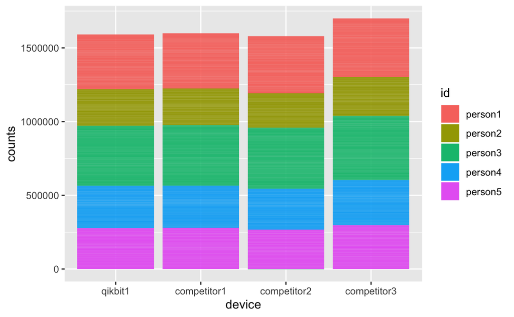

```r
ggplot(qb_device_data, aes(x = device, y = counts, fill = id)) +
  geom_bar(stat = "identity")
```

```r
qb_competitors
```

| Company | Year | Revenue |
| --- | --- | --- |
| Competitor 1 | 2019 | 2216000 |
| Competitor 2 | 2019 | 1760000 |
| Competitor 3 | 2019 | 1455000 |
| Competitor 4 | 2019 | 1229000 |
| Competitor 1 | 2018 | 2144400 |
| Competitor 2 | 2018 | 1440000 |
| Competitor 3 | 2018 | 1555000 |
| Competitor 4 | 2018 | 987000 |
| Competitor 1 | 2017 | 1750000 |
| Competitor 2 | 2017 | 987000 |

[output cut: 10 more lines]

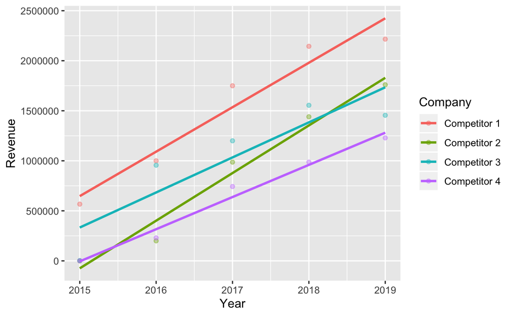

```r
ggplot(qb_competitors, aes(x = Year, y = Revenue, colour = Company)) +
  geom_point(alpha = 0.4) +
  geom_smooth(method = "lm", se = FALSE)
```

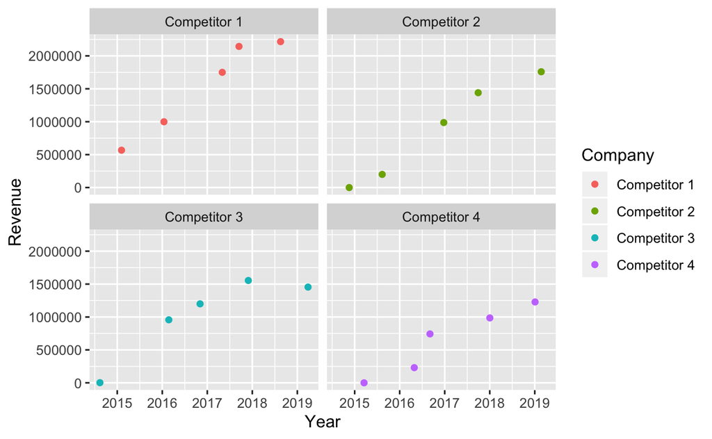

```r
ggplot(qb_competitors, aes(x = Year, y = Revenue, colour = Company)) +
  geom_jitter() +
  facet_wrap(. ~ Company)
```

```r
qb_monthly_sales
```

| Date | Cashflow | Amount |
| --- | --- | --- |
| 2019-07-01 | Kwikbit Unit 1 Sales | 601.74 |
| 2019-06-01 | Kwikbit Unit 1 Sales | 567.89 |
| 2019-05-01 | Kwikbit Unit 1 Sales | 536.00 |
| 2019-04-01 | Kwikbit Unit 1 Sales | 550.78 |
| 2019-03-01 | Kwikbit Unit 1 Sales | 526.03 |
| 2019-02-01 | Kwikbit Unit 1 Sales | 584.22 |
| 2019-01-01 | Kwikbit Unit 1 Sales | 530.76 |
| 2018-12-01 | Kwikbit Unit 1 Sales | 504.80 |
| 2018-11-01 | Kwikbit Unit 1 Sales | 513.67 |
| 2018-10-01 | Kwikbit Unit 1 Sales | 499.99 |

[output cut: 26 more lines]

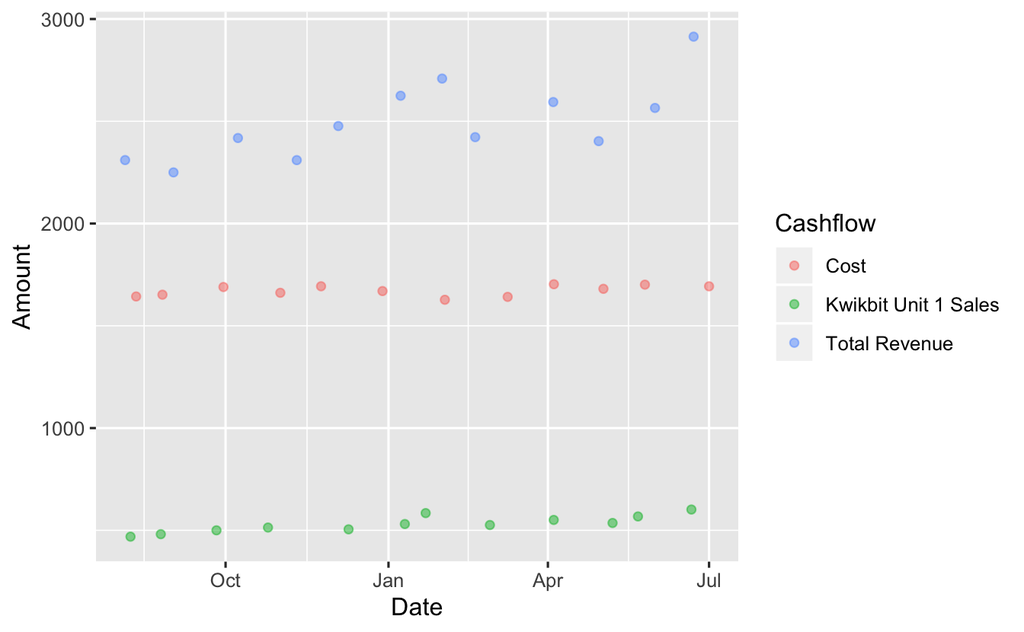

```r
ggplot(qb_monthly_sales, aes(x = Date, y = Amount, colour = Cashflow)) +
  geom_point(alpha = 0.5, position = "jitter")
```